# Replication of People make the Same Bayesian Judgment They Criticize in Others by Cao, Kleiman-Weiner and Banaji (2019, Psychological Science)

## Discussion

### Summary of Replication Attempt

There were two statistical tests involved in this replication, first was the primary replication target, the ANOVA with linear model fit; and the secondary target was the two-tailed t-test. The ANOVA assessed the extent to which the target (man vs woman) and the evaluations of person X (Likert scale from 1 to 7) was related to posterior judgments whereas the t-test assessed the extent to which the evaluations of person X were positive or negative.

### Commentary

In order to understand the partial replication of finding 2, a follow-up exploratory analysis was conducted. This would provide some insight into the failed attempt to replicate figure 4. The figure was plotted a second time, this time including the data points to investigate the point distribution underlying the lines.

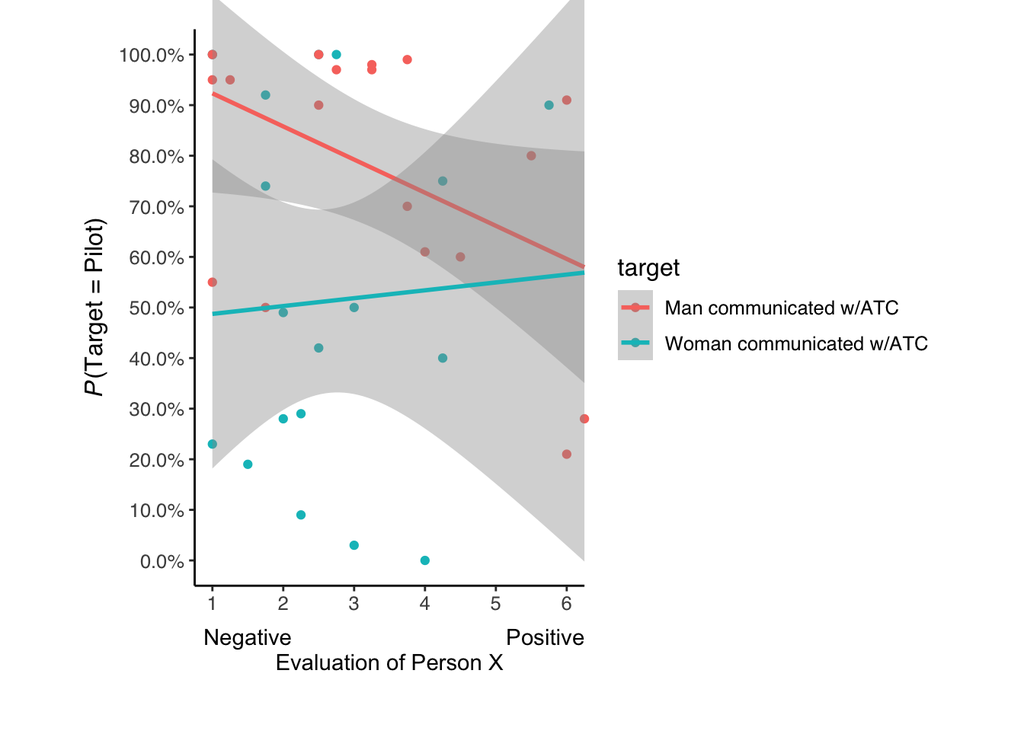

```r
dat %>%
  ggplot(mapping = aes(x = composite.avg, y = posterior_percent, color = target)) +
  geom_point(width=0.2) +
  geom_smooth(method = "lm", se = TRUE, fullrange = TRUE) +
  theme_classic() +
  scale_x_continuous(breaks = seq(1, 7, 1)) +
  scale_y_continuous(breaks = seq(0, 1, 0.10),
                    label = percent_format()) +
  theme(aspect.ratio = 10/7) +
  scale_color_discrete(labels = c("Man communicated w/ATC",
                                  "Woman communicated w/ATC")) +
  annotate("text", c(1.5, 5.7), y = -0.15,
           label = c("Negative", "Positive")) +
  annotate("text", c(3.5), y = -0.2 , label = c("Evaluation of Person X")) +
  coord_cartesian(xlim = c(1, 6), ylim = c(0, 1), clip = "off") +
  labs ( y = expression(paste(italic(P), "(Target = Pilot)"))) +
   theme(plot.margin = unit(c(1, 1, 4, 1), "lines"),
         axis.title.x = element_blank(),
         text=element_text(size=12,  family="sans")
   )
```

It could be argued that finding 2 was technically successfully replicated, since the original finding was simply that male targets were always judged as more likely to be the targets than female targets regardless of evaluation of person X (which was replicated), and that the failure to replicate the trend in figure 4 is a separate issue altogether. Furthermore, it could be argued that a replication of figure 4 wasn’t explicitly stated in the preregistration therefore it shouldn’t be considered at all in this replication. We don’t agree with this analysis because, in the original paper, finding 2 is tied to figure 4, as illustrated by the quote, “But as shown in Figure 4, participants judged that the man was more likely than the woman to be the pilot, regardless of their evaluation of person X, F(1, 344) = 84.58…” This makes a replication of figure 4 an implicit sub-goal of replicating finding 2.

Overall this replication attempt revealed some interesting aspects about the replication process. What does it mean to replicate a figure from a study? The statistical tests could reveal similar results but the figures could still look quite different. Moreover, this experience was a reminder that statistical tests like ANOVAs just identify that there are differences between groups without specifying which particular groups differ and to what extent they do.

As at the writing of this report, the original authors had not been notified of the results of this replication, so it will be interesting to hear what they think about our interpretation.